# Vancouver Airbnb Dataset

## Setup

```python
import os
import sys

venv_name = "venv"

if not os.path.exists(venv_name):
    print(f"Creating virtual environment '{venv_name}'...")
    # We use sys.executable to ensure we use the same python version
    os.system(f"{sys.executable} -m venv {venv_name}")
    print(f"Virtual environment created.")
else:
    print(f"Virtual environment '{venv_name}' already exists.")
```

```
Virtual environment 'venv' already exists.
```

```python
#Auto Install everything I need

packages = [
    "pandas",
    "matplotlib",
    "seaborn",
    "scipy",        # For hypothesis testing
    "plotly",       # For interactive maps
    "folium",       # For alternative interactive maps
    "nbformat",     # The package you were missing for plotly
    "jupyterlab",    # Good to have Jupyter inside the venv
    "ipywidgets",    # For interactive widgets in Jupyter
    "tabulate"     # For better table display in Jupyter
]

# --- Find the correct pip executable ---
if sys.platform == "win32":
    pip_executable = os.path.join(venv_name, "Scripts", "pip.exe")
else:
    pip_executable = os.path.join(venv_name, "bin", "pip")

# --- Install the packages ---
print("Installing packages into the virtual environment...")
for package in packages:
    print(f"Installing {package}...")
    os.system(f"{pip_executable} install {package}")

print("All packages installed.")
```

```
Installing pandas...
Installing matplotlib...
Installing seaborn...
Installing scipy...
Installing plotly...
Installing folium...
Installing nbformat...
Installing jupyterlab...
Installing ipywidgets...
Installing tabulate...
All packages installed.
```

## Import csv

```python
import pandas as pd
import numpy as np

df = pd.read_csv('listings.csv')
df.head(5)
```

|  | id | listing_url | scrape_id | last_scraped | source | name | description | neighborhood_overview | picture_url | host_id | ... | review_scores_communication | review_scores_location | review_scores_value | license | instant_bookable | calculated_host_listings_count | calculated_host_listings_count_entire_homes | calculated_host_listings_count_private_rooms | calculated_host_listings_count_shared_rooms | reviews_per_month |
| --- | --- | --- | --- | --- | --- | --- | --- | --- | --- | --- | --- | --- | --- | --- | --- | --- | --- | --- | --- | --- | --- |
| 0 | 13188 | https://www.airbnb.com/rooms/13188 | 20250810152821 | 2025-08-10 | city scrape | Garden level studio in ideal loc. | Garden level studio suite with garden patio - ... | The uber hip Main street area is a short walk ... | https://a0.muscache.com/pictures/8408188/e1af6... | 51466 | ... | 4.94 | 4.90 | 4.81 | Municipal registration number: 25-156058<br />... | f | 1 | 1 | 0 | 0 | 1.98 |
| 1 | 13358 | https://www.airbnb.com/rooms/13358 | 20250810152821 | 2025-08-10 | city scrape | Downtown Designer one bedroom | The iconic Electra Building.<br />A Vancouver ... | 2 blocks away from the shopping area of Robson... | https://a0.muscache.com/pictures/miso/Hosting-... | 52116 | ... | 4.81 | 4.91 | 4.66 | Municipal registration number: 25-157257<br />... | t | 1 | 1 | 0 | 0 | 3.12 |
| 2 | 16611 | https://www.airbnb.com/rooms/16611 | 20250810152821 | 2025-08-10 | previous scrape | 1 block to skytrain station, shops,restaurant,... | My place is close to bank, coffee shops, groce... | Next block to Commercial Drive which has many ... | https://a0.muscache.com/pictures/82101/7127b63... | 58512 | ... | 4.33 | 5.00 | 3.67 | NaN | f | 5 | 5 | 0 | 0 | 0.03 |
| 3 | 18270 | https://www.airbnb.com/rooms/18270 | 20250810152821 | 2025-08-10 | city scrape | private rm in clean central 2BR apt | I have a bright furnished 2 bedroom suite on a... | Lots of restaurants, coffee shops.<br />Easy a... | https://a0.muscache.com/pictures/108520241/aec... | 70437 | ... | 4.73 | 4.69 | 4.49 | NaN | f | 1 | 0 | 1 | 0 | 0.67 |
| 4 | 18589 | https://www.airbnb.com/rooms/18589 | 20250810152821 | 2025-08-10 | city scrape | Commercial Drive B&B | As hosts, we are welcoming you into our home, ... | Lots of restaurants and boutiques just outside... | https://a0.muscache.com/pictures/dd3ca406-cb74... | 71508 | ... | 5.00 | 4.93 | 4.96 | Municipal registration number: 25-155972<br />... | f | 1 | 0 | 1 | 0 | 3.57 |

5 rows × 79 columns

```python
df.info()
```

```
<class 'pandas.core.frame.DataFrame'>
RangeIndex: 5550 entries, 0 to 5549
Data columns (total 79 columns):
 #   Column                                        Non-Null Count  Dtype
---  ------                                        --------------  -----
 0   id                                            5550 non-null   int64
 1   listing_url                                   5550 non-null   object
 2   scrape_id                                     5550 non-null   int64
 3   last_scraped                                  5550 non-null   object
 4   source                                        5550 non-null   object
 5   name                                          5550 non-null   object
 6   description                                   5489 non-null   object
 7   neighborhood_overview                         2802 non-null   object
 8   picture_url                                   5550 non-null   object
 9   host_id                                       5550 non-null   int64
```

[output cut: 71 more lines]

```python
df.describe()
```

|  | id | scrape_id | host_id | host_listings_count | host_total_listings_count | neighbourhood_group_cleansed | latitude | longitude | accommodates | bathrooms | ... | review_scores_cleanliness | review_scores_checkin | review_scores_communication | review_scores_location | review_scores_value | calculated_host_listings_count | calculated_host_listings_count_entire_homes | calculated_host_listings_count_private_rooms | calculated_host_listings_count_shared_rooms | reviews_per_month |
| --- | --- | --- | --- | --- | --- | --- | --- | --- | --- | --- | --- | --- | --- | --- | --- | --- | --- | --- | --- | --- | --- |
| count | 5.550000e+03 | 5.550000e+03 | 5.550000e+03 | 5548.000000 | 5548.000000 | 0.0 | 5550.000000 | 5550.000000 | 5550.000000 | 4646.000000 | ... | 4823.000000 | 4823.000000 | 4823.000000 | 4823.000000 | 4823.000000 | 5550.000000 | 5550.000000 | 5550.000000 | 5550.000000 | 4824.000000 |
| mean | 7.212136e+17 | 2.025081e+13 | 2.486465e+08 | 12.339041 | 20.724225 | NaN | 49.261179 | -123.111347 | 3.674955 | 1.352023 | ... | 4.744676 | 4.840278 | 4.854078 | 4.809140 | 4.645685 | 8.292973 | 6.601982 | 1.672793 | 0.016577 | 1.959745 |
| std | 5.640347e+17 | 0.000000e+00 | 2.225780e+08 | 37.943111 | 57.532584 | NaN | 0.021399 | 0.040218 | 2.120093 | 0.688599 | ... | 0.469888 | 0.336280 | 0.374847 | 0.298626 | 0.468471 | 24.473028 | 24.005675 | 5.965688 | 0.231146 | 1.877323 |
| min | 1.318800e+04 | 2.025081e+13 | 6.033000e+03 | 1.000000 | 1.000000 | NaN | 49.202270 | -123.223370 | 1.000000 | 0.000000 | ... | 1.000000 | 1.000000 | 1.000000 | 1.000000 | 1.000000 | 1.000000 | 0.000000 | 0.000000 | 0.000000 | 0.010000 |
| 25% | 4.229575e+07 | 2.025081e+13 | 3.899611e+07 | 1.000000 | 1.000000 | NaN | 49.247595 | -123.130649 | 2.000000 | 1.000000 | ... | 4.720000 | 4.820000 | 4.865000 | 4.760000 | 4.600000 | 1.000000 | 1.000000 | 0.000000 | 0.000000 | 0.340000 |
| 50% | 8.777264e+17 | 2.025081e+13 | 1.952416e+08 | 2.000000 | 3.000000 | NaN | 49.266691 | -123.112210 | 4.000000 | 1.000000 | ... | 4.880000 | 4.930000 | 4.960000 | 4.890000 | 4.750000 | 1.000000 | 1.000000 | 0.000000 | 0.000000 | 1.460000 |
| 75% | 1.225518e+18 | 2.025081e+13 | 4.535973e+08 | 5.000000 | 8.000000 | NaN | 49.278892 | -123.086756 | 4.000000 | 2.000000 | ... | 4.980000 | 5.000000 | 5.000000 | 5.000000 | 4.870000 | 4.000000 | 2.000000 | 1.000000 | 0.000000 | 3.040000 |
| max | 1.483828e+18 | 2.025081e+13 | 7.122721e+08 | 766.000000 | 943.000000 | NaN | 49.294360 | -123.023530 | 16.000000 | 8.000000 | ... | 5.000000 | 5.000000 | 5.000000 | 5.000000 | 5.000000 | 147.000000 | 147.000000 | 51.000000 | 5.000000 | 15.460000 |

8 rows × 44 columns

```python
# % missing by column
na_rate = df.isna().mean().sort_values(ascending=False)
na_rate.head(20)
```

```
neighbourhood_group_cleansed    1.000000
calendar_updated                1.000000
host_about                      0.498739
neighborhood_overview           0.495135
neighbourhood                   0.495135
host_location                   0.232973
license                         0.216216
estimated_revenue_l365d         0.164144
price                           0.164144
bathrooms                       0.162883
beds                            0.162523
host_response_time              0.150090
host_response_rate              0.150090
review_scores_communication     0.130991
review_scores_location          0.130991
review_scores_cleanliness       0.130991
review_scores_accuracy          0.130991
review_scores_checkin           0.130991
review_scores_value             0.130991
last_review                     0.130811
dtype: float64
```

```python
# constant / near-constant features
nunique = df.nunique(dropna=False).sort_values()
const_cols = nunique[nunique<=1].index.tolist()
const_cols
```

```
['last_scraped',
 'scrape_id',
 'neighbourhood_group_cleansed',
 'calendar_last_scraped',
 'calendar_updated']
```

### Initial Insights/First Impressions:

A lot of columns are regarding metadata I don't neccessarily need or would not be practical for an analysis. For example:

id: Pandas already assigns each row an ID. The ID in the dataset isn't correlated with the item. For example, "13188" doesn't really say anything about the property. It's just as arbitary as Pandas assigning it an index value of 0.

The same applies to scrape_id (which seems to use the timestamp of last_scraped as it's 20250810152821 vs 2025-08-10), last_scraped. I don't think it's relevant to know what scraped the data. The data is here therefore it is scraped.

Host metadata: Columns like host_thumbnail_url, host_picture_url and arguably even host_name are unnessary. Aside from being images (well, links to images that don't even show up in the dataset). In any case, I don't believe how a URL is formatted is affecting the success of an AirBnb Property so I believe these columns should be dropped.

However, I believe columns like host_has_profile_pic, host_identity_verified, host_response_rate, host_is_superhost, host_since etc would be more relevant in the success of an airbnb property. It's a reasonable assumption that a verified host that's been active a long time would likely attract more tenants and one worth investigating

Latitude/Longitude: I believe these columns are redundant because the column "neighbourhood_cleansed" provides the rough location for a property. For example, the property at 49.24773, -123.10509 is 500 metres from the "neighbourhood_cleansed" location "Riley Park". So I can drop latitude and longitude and instead rely on neighbourhood_cleansed for location information. That being said, A bonus feature could be analyzing how far each property from a point of interest such as downtown. I might keep that in the back.

Property name, description, amenities and even host_description could be candidates for sentiment analysis?

Price isn't stored as a float lol. The dates don't seem to be stored as datetimes. T/F Columns could be made into Booleans

neighbourhood_group_cleansed and calendar_updated are entirely blank.

neighbourhood is either blank or "Neighborhood highlights". So it can be dropped

Columns such as reviews are highly correlated. Columns such as availability has one for 30 days, 60 days, 90 days and 365 days. More analysis needs to be done on how to handle that.

Host verification and Host Verification methods seem redundant. I am going to assume it doesn't matter how a host gets verified (since most either use their email or phone to do it. The specifics doesn't matter)

So many stats for bedrooms, bathrooms and accomodates. I could make columns that are more useful like "'beds_per_guest'", baths_per_guest, price_per_guest etc

host_response_time is text (e.g within the hour). As is host_response_rate and host_acceptance_rate (100%. I could make these scale from 0-1)

All the "calculated_host_listings_count calculated_host_listings_count_entire_homes calculated_host_listings_count_private_rooms calculated_host_listings_count_shared_rooms" ones are redundant when we already have the total host listings column

# Part 1: Dropping the most Unnessary, Redundant or unhelpful Columns. Fixing Datatypes, Booleans and datetimes. Some Graphing

```python
#columns_to_drop = ['last_scraped', 'scrape_id', 'neighbourhood_group_cleansed', 'calendar_last_scraped', 'calendar_updated', 'host_thumbnail_url', 'host_picture_url', 'host_url', 'host_name', 'source', 'longitude', 'latitude', 'host_verifications', 'listing_url', 'picture_url', 'neighbourhood', 'calculated_host_listings_count_entire_homes', 'calculated_host_listings_count_private_rooms', 'calculated_host_listings_count_shared_rooms', 'calculated_host_listings_count', 'host_listings_count', 'availability_30', 'availability_60', 'availability_90', 'availability_eoy', 'license']

columns_to_drop = ['last_scraped', 'scrape_id', 'neighbourhood_group_cleansed', 'calendar_last_scraped', 'calendar_updated', 'host_thumbnail_url', 'host_picture_url', 'host_url', 'host_name', 'source',  'host_verifications', 'listing_url', 'picture_url', 'neighbourhood', 'calculated_host_listings_count_entire_homes', 'calculated_host_listings_count_private_rooms', 'calculated_host_listings_count_shared_rooms', 'calculated_host_listings_count', 'host_listings_count', 'availability_30', 'availability_60', 'availability_90', 'availability_eoy', 'license']


df = df.drop(columns=columns_to_drop)
df.shape
```

```
(5550, 55)
```

## Data Type Fixes

### Fixing Price

```python
#Convert Price to float
df['price'] = df['price'].str.replace('$', '').str.replace(',', '').astype(float)
df['price'].head()
```

```
0    141.0
1    274.0
2      NaN
3     47.0
4    160.0
Name: price, dtype: float64
```

### Convert Date Columns to datetime

```python
# Convert Date Columns to datetime
date_cols = ['host_since', 'first_review', 'last_review']
for col in date_cols:
    df[col] = pd.to_datetime(df[col], errors='coerce')
df[date_cols].info()
```

```
<class 'pandas.core.frame.DataFrame'>
RangeIndex: 5550 entries, 0 to 5549
Data columns (total 3 columns):
 #   Column        Non-Null Count  Dtype
---  ------        --------------  -----
 0   host_since    5548 non-null   datetime64[ns]
 1   first_review  4824 non-null   datetime64[ns]
 2   last_review   4824 non-null   datetime64[ns]
dtypes: datetime64[ns](3)
memory usage: 130.2 KB
```

### Convert t/fs to Booleans

```python
# Convert t/fs and 1/0 to Booleans
bool_cols = ['host_is_superhost', 'host_has_profile_pic', 'host_identity_verified', 'instant_bookable', 'has_availability']

for col in bool_cols:
    df[col] = df[col].map({'t': True, 'f': False, 1: True, 0: False}).astype(bool)
df[bool_cols].info()
```

```
<class 'pandas.core.frame.DataFrame'>
RangeIndex: 5550 entries, 0 to 5549
Data columns (total 5 columns):
 #   Column                  Non-Null Count  Dtype
---  ------                  --------------  -----
 0   host_is_superhost       5550 non-null   bool
 1   host_has_profile_pic    5550 non-null   bool
 2   host_identity_verified  5550 non-null   bool
 3   instant_bookable        5550 non-null   bool
 4   has_availability        5550 non-null   bool
dtypes: bool(5)
memory usage: 27.2 KB
```

```python
df.info()
```

```
<class 'pandas.core.frame.DataFrame'>
RangeIndex: 5550 entries, 0 to 5549
Data columns (total 55 columns):
 #   Column                       Non-Null Count  Dtype
---  ------                       --------------  -----
 0   id                           5550 non-null   int64
 1   name                         5550 non-null   object
 2   description                  5489 non-null   object
 3   neighborhood_overview        2802 non-null   object
 4   host_id                      5550 non-null   int64
 5   host_since                   5548 non-null   datetime64[ns]
 6   host_location                4257 non-null   object
 7   host_about                   2782 non-null   object
 8   host_response_time           4717 non-null   object
 9   host_response_rate           4717 non-null   object
```

[output cut: 47 more lines]

```python
df.head()
```

|  | id | name | description | neighborhood_overview | host_id | host_since | host_location | host_about | host_response_time | host_response_rate | ... | last_review | review_scores_rating | review_scores_accuracy | review_scores_cleanliness | review_scores_checkin | review_scores_communication | review_scores_location | review_scores_value | instant_bookable | reviews_per_month |
| --- | --- | --- | --- | --- | --- | --- | --- | --- | --- | --- | --- | --- | --- | --- | --- | --- | --- | --- | --- | --- | --- |
| 0 | 13188 | Garden level studio in ideal loc. | Garden level studio suite with garden patio - ... | The uber hip Main street area is a short walk ... | 51466 | 2009-11-04 | Vancouver, Canada | I love to travel with my family in comfort and... | within an hour | 100% | ... | 2025-08-08 | 4.85 | 4.88 | 4.86 | 4.87 | 4.94 | 4.90 | 4.81 | False | 1.98 |
| 1 | 13358 | Downtown Designer one bedroom | The iconic Electra Building.<br />A Vancouver ... | 2 blocks away from the shopping area of Robson... | 52116 | 2009-11-07 | Vancouver, Canada | I am from Vancouver and in my free time I enjo... | within an hour | 100% | ... | 2025-06-22 | 4.71 | 4.77 | 4.82 | 4.83 | 4.81 | 4.91 | 4.66 | True | 3.12 |
| 2 | 16611 | 1 block to skytrain station, shops,restaurant,... | My place is close to bank, coffee shops, groce... | Next block to Commercial Drive which has many ... | 58512 | 2009-11-29 | NaN | NaN | NaN | NaN | ... | 2018-02-16 | 4.00 | 4.00 | 3.00 | 4.00 | 4.33 | 5.00 | 3.67 | False | 0.03 |
| 3 | 18270 | private rm in clean central 2BR apt | I have a bright furnished 2 bedroom suite on a... | Lots of restaurants, coffee shops.<br />Easy a... | 70437 | 2010-01-14 | Vancouver, Canada | In my spare time I am pretty active - currentl... | NaN | NaN | ... | 2019-12-31 | 4.54 | 4.50 | 3.98 | 4.75 | 4.73 | 4.69 | 4.49 | False | 0.67 |
| 4 | 18589 | Commercial Drive B&B | As hosts, we are welcoming you into our home, ... | Lots of restaurants and boutiques just outside... | 71508 | 2010-01-18 | Vancouver, Canada | We - Alexis and Sylvain - are the Artistic Dir... | within an hour | 100% | ... | 2025-08-05 | 4.98 | 4.97 | 4.98 | 4.99 | 5.00 | 4.93 | 4.96 | False | 3.57 |

5 rows × 55 columns

## Analyzing review Score columns

```python
# columns containing "review"
review_cols = [c for c in df.columns if "review" in c.lower()]

# 1) Peek at just the review columns
df[review_cols].head(5)
```

|  | number_of_reviews | number_of_reviews_ltm | number_of_reviews_l30d | number_of_reviews_ly | first_review | last_review | review_scores_rating | review_scores_accuracy | review_scores_cleanliness | review_scores_checkin | review_scores_communication | review_scores_location | review_scores_value | reviews_per_month |
| --- | --- | --- | --- | --- | --- | --- | --- | --- | --- | --- | --- | --- | --- | --- |
| 0 | 372 | 51 | 7 | 60 | 2010-02-21 | 2025-08-08 | 4.85 | 4.88 | 4.86 | 4.87 | 4.94 | 4.90 | 4.81 | 1.98 |
| 1 | 575 | 43 | 0 | 56 | 2010-06-22 | 2025-06-22 | 4.71 | 4.77 | 4.82 | 4.83 | 4.81 | 4.91 | 4.66 | 3.12 |
| 2 | 3 | 0 | 0 | 0 | 2017-12-24 | 2018-02-16 | 4.00 | 4.00 | 3.00 | 4.00 | 4.33 | 5.00 | 3.67 | 0.03 |
| 3 | 118 | 0 | 0 | 0 | 2011-03-17 | 2019-12-31 | 4.54 | 4.50 | 3.98 | 4.75 | 4.73 | 4.69 | 4.49 | 0.67 |
| 4 | 616 | 54 | 4 | 71 | 2011-06-06 | 2025-08-05 | 4.98 | 4.97 | 4.98 | 4.99 | 5.00 | 4.93 | 4.96 | 3.57 |

It appears that the columns that measure an individual property's review (e.g review_scores_accuracy review_scores_cleanliness review_scores_checkin review_scores_communication etc) are tightly correlated. I should check that and decide if they should be dropped or merged into an average review score

```python
# pick only the rating columns that exist
score_cols = [c for c in [
    'review_scores_rating','review_scores_accuracy','review_scores_cleanliness',
    'review_scores_checkin','review_scores_communication','review_scores_location',
    'review_scores_value'
] if c in df.columns]

# correlation matrix
corr_scores = df[score_cols].corr()
print(corr_scores.round(3))

# how strongly each sub-score relates to overall rating
if 'review_scores_rating' in score_cols:
    print("\nCorrelations vs overall:")
    print(corr_scores['review_scores_rating'].sort_values(ascending=False).round(3))
```

```
                             review_scores_rating  review_scores_accuracy  \
review_scores_rating                        1.000                   0.906
review_scores_accuracy                      0.906                   1.000
review_scores_cleanliness                   0.858                   0.825
review_scores_checkin                       0.719                   0.726
review_scores_communication                 0.831                   0.797
review_scores_location                      0.605                   0.584
review_scores_value                         0.898                   0.870

                             review_scores_cleanliness  review_scores_checkin  \
review_scores_rating                             0.858                  0.719
review_scores_accuracy                           0.825                  0.726
review_scores_cleanliness                        1.000                  0.646
review_scores_checkin                            0.646                  1.000
review_scores_communication                      0.743                  0.752
review_scores_location                           0.531                  0.559
review_scores_value                              0.814                  0.689

                             review_scores_communication  \
review_scores_rating                               0.831
review_scores_accuracy                             0.797
review_scores_cleanliness                          0.743
review_scores_checkin                              0.752
review_scores_communication                        1.000
review_scores_location                             0.532
review_scores_value                                0.765

                             review_scores_location  review_scores_value
review_scores_rating                          0.605                0.898
review_scores_accuracy                        0.584                0.870
review_scores_cleanliness                     0.531                0.814
review_scores_checkin                         0.559                0.689
review_scores_communication                   0.532                0.765
review_scores_location                        1.000                0.584
review_scores_value                           0.584                1.000

Correlations vs overall:
review_scores_rating           1.000
review_scores_accuracy         0.906
review_scores_value            0.898
review_scores_cleanliness      0.858
review_scores_communication    0.831
review_scores_checkin          0.719
review_scores_location         0.605
Name: review_scores_rating, dtype: float64
```

Yeah. It looks like review scores are genrally quite correlated. I can combine them into a single column called "average_review_score"

```python
# Take the columns in score_cols  and average them into a new column called 'average_review_score'. Drop the original columns
df['average_review_score'] = df[score_cols].mean(axis=1)
df = df.drop(columns=score_cols)
df[['average_review_score']].head()
```

|  | average_review_score |
| --- | --- |
| 0 | 4.872857 |
| 1 | 4.787143 |
| 2 | 4.000000 |
| 3 | 4.525714 |
| 4 | 4.972857 |

## Analyzing Review Time Columns

A lot of redundant columns and ones we can calc. I think a more suitable one is to keep just "number_of_reviews" and use it alongside other columns to create a "reviews per year" column.

```python
today = pd.Timestamp('2025-10-06')

# Ensure dates are parsed
for c in ['first_review','last_review']:
    if c in df.columns:
        df[c] = pd.to_datetime(df[c], errors='coerce')

# Active window for reviews: from first_review to last_review (fallbacks included)
start = df['first_review']
end = df['last_review'].fillna(today)              # if no last_review, treat as still active
days_active = (end - start).dt.days

# Avoid div-by-zero/negatives (brand-new or malformed rows)
days_active = days_active.clip(lower=1)

# Reviews per year
df['reviews_per_year'] = df['number_of_reviews'] / (days_active / 365.25)
df.info()
```

```
<class 'pandas.core.frame.DataFrame'>
RangeIndex: 5550 entries, 0 to 5549
Data columns (total 50 columns):
 #   Column                     Non-Null Count  Dtype
---  ------                     --------------  -----
 0   id                         5550 non-null   int64
 1   name                       5550 non-null   object
 2   description                5489 non-null   object
 3   neighborhood_overview      2802 non-null   object
 4   host_id                    5550 non-null   int64
 5   host_since                 5548 non-null   datetime64[ns]
 6   host_location              4257 non-null   object
 7   host_about                 2782 non-null   object
 8   host_response_time         4717 non-null   object
 9   host_response_rate         4717 non-null   object
```

[output cut: 42 more lines]

Looks good. I can now drop all the other columns regarding review stats

```python
cols_to_drop = ['first_review', 'last_review', 'number_of_reviews_ltm', 'number_of_reviews_l30d', 'number_of_reviews_ly', 'reviews_per_month']
df = df.drop(columns=cols_to_drop)
df.info()
```

```
<class 'pandas.core.frame.DataFrame'>
RangeIndex: 5550 entries, 0 to 5549
Data columns (total 44 columns):
 #   Column                     Non-Null Count  Dtype
---  ------                     --------------  -----
 0   id                         5550 non-null   int64
 1   name                       5550 non-null   object
 2   description                5489 non-null   object
 3   neighborhood_overview      2802 non-null   object
 4   host_id                    5550 non-null   int64
 5   host_since                 5548 non-null   datetime64[ns]
 6   host_location              4257 non-null   object
 7   host_about                 2782 non-null   object
 8   host_response_time         4717 non-null   object
 9   host_response_rate         4717 non-null   object
```

[output cut: 36 more lines]

## Max/Min Nights

There's 8 columns on how many min/max nights a guest can stay. Lets see if we can get any info out of them

```python
# columns containing "night"
night_cols = [c for c in df.columns if "night" in c.lower()]

# 1) Peek at just the night columns
df[night_cols].head(5)
```

|  | minimum_nights | maximum_nights | minimum_minimum_nights | maximum_minimum_nights | minimum_maximum_nights | maximum_maximum_nights | minimum_nights_avg_ntm | maximum_nights_avg_ntm |
| --- | --- | --- | --- | --- | --- | --- | --- | --- |
| 0 | 2 | 180 | 1.0 | 2.0 | 180.0 | 180.0 | 2.0 | 180.0 |
| 1 | 1 | 1125 | 1.0 | 2.0 | 1125.0 | 1125.0 | 2.0 | 1125.0 |
| 2 | 365 | 365 | 365.0 | 365.0 | 365.0 | 365.0 | 365.0 | 365.0 |
| 3 | 90 | 1125 | 90.0 | 90.0 | 1125.0 | 1125.0 | 90.0 | 1125.0 |
| 4 | 1 | 40 | 1.0 | 2.0 | 1125.0 | 1125.0 | 1.0 | 1125.0 |

The columns that aren't min/max seem to average stats and are super correlated. I can safely drop them

```python
cols_to_drop = ['minimum_minimum_nights', 'maximum_minimum_nights', 'minimum_maximum_nights', 'maximum_maximum_nights', 'minimum_nights_avg_ntm', 'maximum_nights_avg_ntm']
df = df.drop(columns=cols_to_drop)
df.info()
```

```
<class 'pandas.core.frame.DataFrame'>
RangeIndex: 5550 entries, 0 to 5549
Data columns (total 38 columns):
 #   Column                     Non-Null Count  Dtype
---  ------                     --------------  -----
 0   id                         5550 non-null   int64
 1   name                       5550 non-null   object
 2   description                5489 non-null   object
 3   neighborhood_overview      2802 non-null   object
 4   host_id                    5550 non-null   int64
 5   host_since                 5548 non-null   datetime64[ns]
 6   host_location              4257 non-null   object
 7   host_about                 2782 non-null   object
 8   host_response_time         4717 non-null   object
 9   host_response_rate         4717 non-null   object
```

[output cut: 30 more lines]

## Host Response Time and Rate.

The column host_response_time is text (e.g within the hour). I want to see what unique entries there and possibly make it numeric with a "max_host_response_time".

As is host_response_rate and host_acceptance_rate (100%. I could make these scale from 0-1)

```python
df['host_response_time'].unique()
```

```
array(['within an hour', nan, 'a few days or more', 'within a few hours',
       'within a day'], dtype=object)
```

The times seem to be 'within an hour', nan, 'a few days or more', 'within a few hours', 'within a day'. I could map within an hour to 1 (for 1 hour max), a few days or more to 168 (assuming a week's wait). 'within a few hours' I am assuming 6 hours max. And 'within a day' to be 24 hours max. Nan I am going to leave Nan (assuming the host never replies)

```python
time_map = {
    'within an hour': 1,
    'within a few hours': 6,
    'within a day': 24,
    'a few days or more': 168
}
df['max_host_response_time_hours'] = df['host_response_time'].map(time_map)
df = df.drop(columns=['host_response_time'])
df.info()
```

```
<class 'pandas.core.frame.DataFrame'>
RangeIndex: 5550 entries, 0 to 5549
Data columns (total 38 columns):
 #   Column                        Non-Null Count  Dtype
---  ------                        --------------  -----
 0   id                            5550 non-null   int64
 1   name                          5550 non-null   object
 2   description                   5489 non-null   object
 3   neighborhood_overview         2802 non-null   object
 4   host_id                       5550 non-null   int64
 5   host_since                    5548 non-null   datetime64[ns]
 6   host_location                 4257 non-null   object
 7   host_about                    2782 non-null   object
 8   host_response_rate            4717 non-null   object
 9   host_acceptance_rate          4924 non-null   object
```

[output cut: 30 more lines]

```python
# Now for host_response_rate and host_acceptance_rate (both are percentages as strings like '100%')
rate_cols = ['host_response_rate', 'host_acceptance_rate']
for col in rate_cols:
    if col in df.columns:
        df[col] = df[col].str.replace('%', '').astype(float) / 100.0
df[rate_cols].head()
```

|  | host_response_rate | host_acceptance_rate |
| --- | --- | --- |
| 0 | 1.0 | 1.0 |
| 1 | 1.0 | 1.0 |
| 2 | NaN | NaN |
| 3 | NaN | NaN |
| 4 | 1.0 | 1.0 |

## Now for Some Final Summaries and Statsical Analysis

```python
#Now for Some Final Summaries and Statsical Analysis

df.info()
```

```
<class 'pandas.core.frame.DataFrame'>
RangeIndex: 5550 entries, 0 to 5549
Data columns (total 38 columns):
 #   Column                        Non-Null Count  Dtype
---  ------                        --------------  -----
 0   id                            5550 non-null   int64
 1   name                          5550 non-null   object
 2   description                   5489 non-null   object
 3   neighborhood_overview         2802 non-null   object
 4   host_id                       5550 non-null   int64
 5   host_since                    5548 non-null   datetime64[ns]
 6   host_location                 4257 non-null   object
 7   host_about                    2782 non-null   object
 8   host_response_rate            4717 non-null   float64
 9   host_acceptance_rate          4924 non-null   float64
```

[output cut: 30 more lines]

```python
df.describe()
```

|  | id | host_id | host_since | host_response_rate | host_acceptance_rate | host_total_listings_count | latitude | longitude | accommodates | bathrooms | ... | price | minimum_nights | maximum_nights | availability_365 | number_of_reviews | estimated_occupancy_l365d | estimated_revenue_l365d | average_review_score | reviews_per_year | max_host_response_time_hours |
| --- | --- | --- | --- | --- | --- | --- | --- | --- | --- | --- | --- | --- | --- | --- | --- | --- | --- | --- | --- | --- | --- |
| count | 5.550000e+03 | 5.550000e+03 | 5548 | 4717.000000 | 4924.000000 | 5548.000000 | 5550.000000 | 5550.000000 | 5550.000000 | 4646.000000 | ... | 4639.000000 | 5550.000000 | 5550.000000 | 5550.000000 | 5550.000000 | 5550.000000 | 4.639000e+03 | 4824.000000 | 4824.000000 | 4717.000000 |
| mean | 7.212136e+17 | 2.486465e+08 | 2018-08-08 21:51:00.129776384 | 0.962546 | 0.893280 | 20.724225 | 49.261179 | -123.111347 | 3.674955 | 1.352023 | ... | 289.427678 | 39.304685 | 398.327207 | 170.053514 | 53.624685 | 117.156757 | 3.714505e+04 | 4.777559 | 56.105166 | 6.623702 |
| min | 1.318800e+04 | 6.033000e+03 | 2009-01-05 00:00:00 | 0.000000 | 0.000000 | 1.000000 | 49.202270 | -123.223370 | 1.000000 | 0.000000 | ... | 14.000000 | 1.000000 | 2.000000 | 0.000000 | 0.000000 | 0.000000 | 0.000000e+00 | 1.000000 | 0.473244 | 1.000000 |
| 25% | 4.229575e+07 | 3.899611e+07 | 2015-07-24 00:00:00 | 1.000000 | 0.910000 | 1.000000 | 49.247595 | -123.130649 | 2.000000 | 1.000000 | ... | 133.000000 | 2.000000 | 90.000000 | 55.000000 | 3.000000 | 0.000000 | 3.630000e+03 | 4.762500 | 10.093582 | 1.000000 |
| 50% | 8.777264e+17 | 1.952416e+08 | 2018-06-13 12:00:00 | 1.000000 | 0.980000 | 3.000000 | 49.266691 | -123.112210 | 4.000000 | 1.000000 | ... | 210.000000 | 3.000000 | 365.000000 | 161.000000 | 19.000000 | 108.000000 | 2.346000e+04 | 4.860000 | 28.525899 | 1.000000 |
| 75% | 1.225518e+18 | 4.535973e+08 | 2022-04-10 12:00:00 | 1.000000 | 1.000000 | 8.000000 | 49.278892 | -123.086756 | 4.000000 | 2.000000 | ... | 338.500000 | 90.000000 | 365.000000 | 274.000000 | 69.000000 | 234.000000 | 4.635000e+04 | 4.931429 | 53.186756 | 1.000000 |
| max | 1.483828e+18 | 7.122721e+08 | 2025-08-08 00:00:00 | 1.000000 | 1.000000 | 943.000000 | 49.294360 | -123.023530 | 16.000000 | 8.000000 | ... | 64360.000000 | 399.000000 | 1125.000000 | 365.000000 | 1102.000000 | 255.000000 | 1.641180e+07 | 5.000000 | 730.500000 | 168.000000 |
| std | 5.640347e+17 | 2.225780e+08 | NaN | 0.149769 | 0.207894 | 57.532584 | 0.021399 | 0.040218 | 2.120093 | 0.688599 | ... | 1043.364323 | 49.398457 | 364.306085 | 122.717126 | 88.676272 | 102.637810 | 2.529879e+05 | 0.356280 | 92.417188 | 24.823179 |

8 rows × 22 columns

```python
import matplotlib.pyplot as plt
import seaborn as sns

#Some Helper Functions

def topk_counts(s, k=15):
    return s.value_counts(dropna=False).head(k)[::-1]

def save_show(title, fname=None):
    plt.title(title)
    plt.tight_layout()
    if fname: plt.savefig(fname, dpi=150)
    plt.show()
```

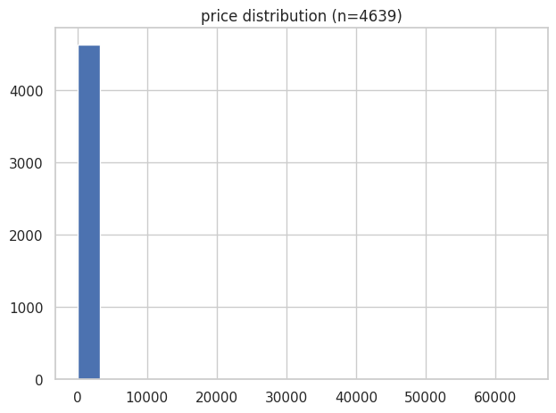

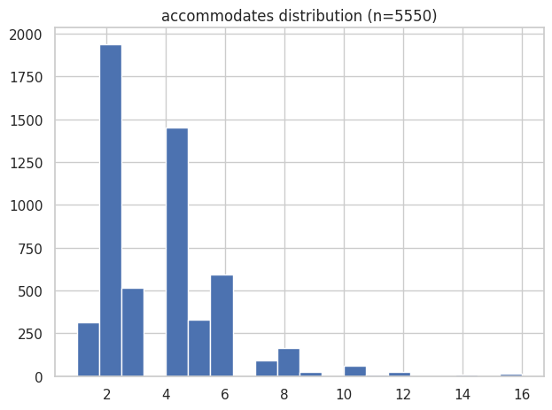

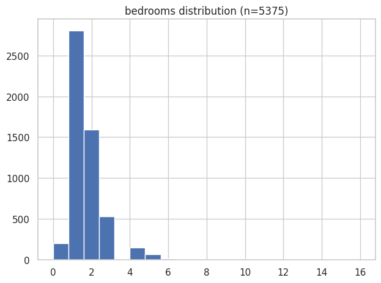

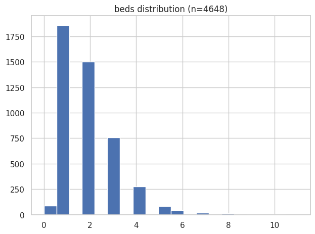

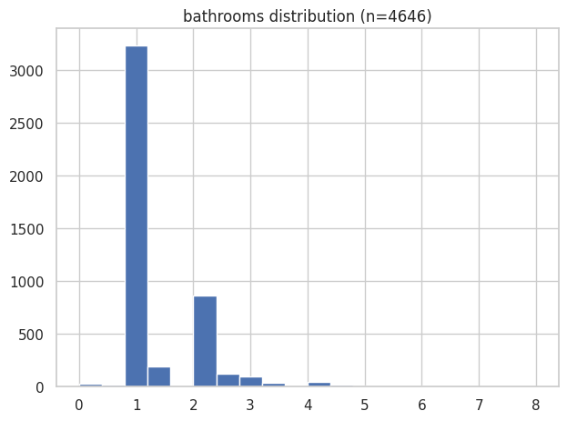

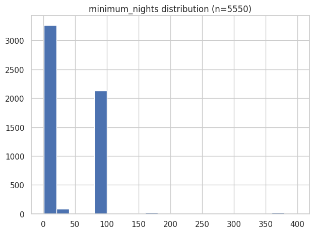

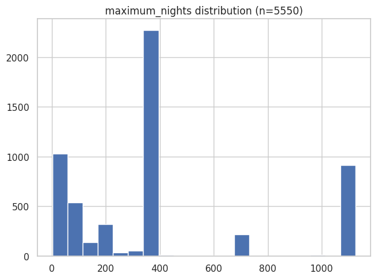

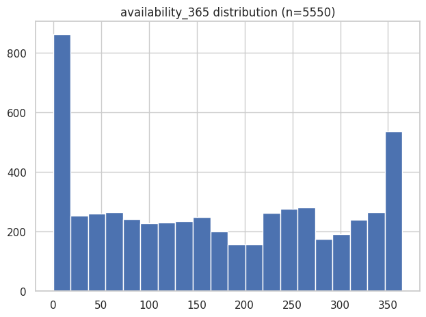

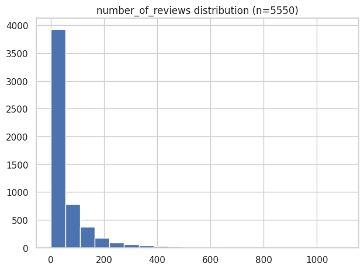

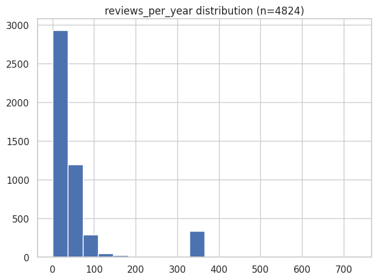

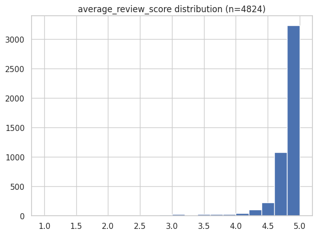

```python
# Numerical columns to plot distributions for

num_cols = ['price','accommodates','bedrooms','beds','bathrooms',
            'minimum_nights','maximum_nights','availability_365',
            'number_of_reviews','reviews_per_year','average_review_score']

for c in [x for x in num_cols if x in df.columns]:
    s = df[c].dropna()
    plt.figure()
    plt.hist(s, bins=20)
    save_show(f'{c} distribution (n={len(s)})')
```

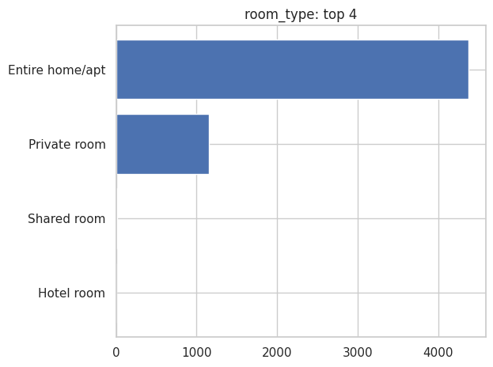

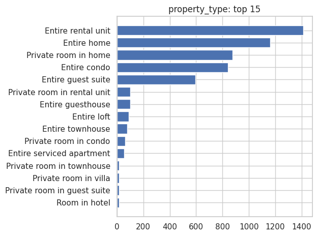

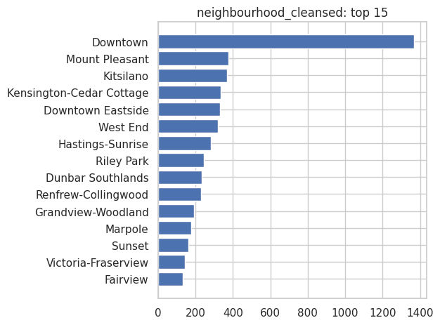

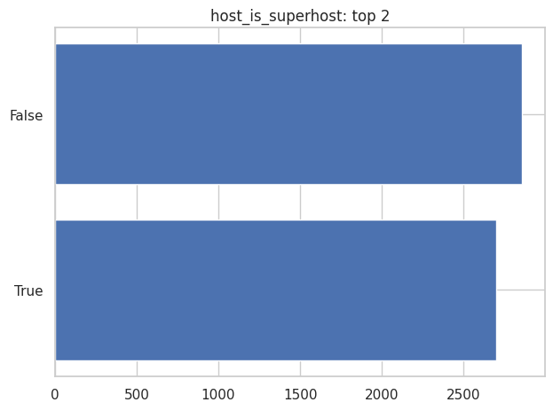

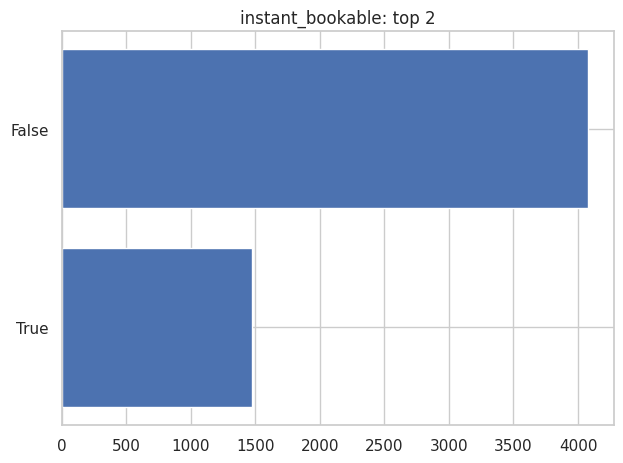

```python
#Categorical columns to plot distributions for
for c in ['room_type','property_type','neighbourhood_cleansed','host_is_superhost','instant_bookable']:
    if c in df.columns:
        vc = topk_counts(df[c], 15)
        plt.figure()
        plt.barh(vc.index.astype(str), vc.values)
        save_show(f'{c}: top {len(vc)}')
```

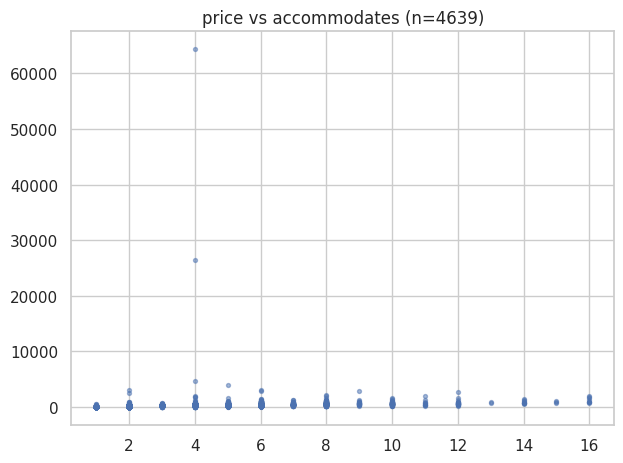

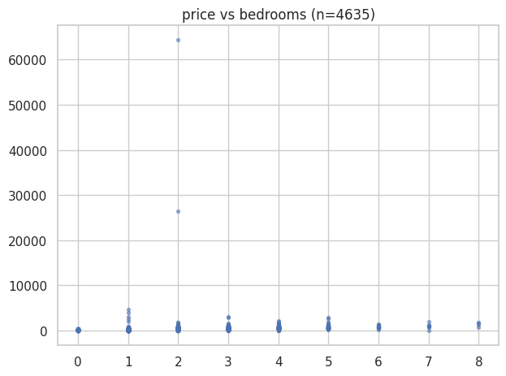

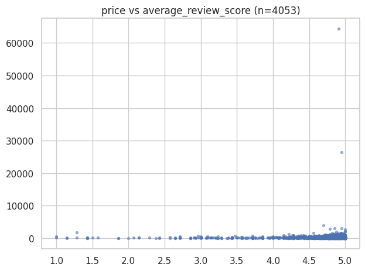

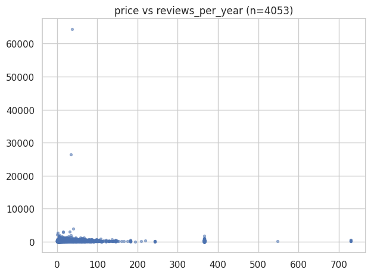

```python
#Scatter plot for price and some numerical columns
pairs = [
    ('accommodates','price'),
    ('bedrooms','price'),
    ('average_review_score','price'),
    ('reviews_per_year','price')
]
for x,y in pairs:
    if x in df.columns and y in df.columns:
        d = df[[x,y]].dropna()
        plt.figure()
        plt.scatter(d[x], d[y], s=8, alpha=0.5)
        save_show(f'{y} vs {x} (n={len(d)})')
```

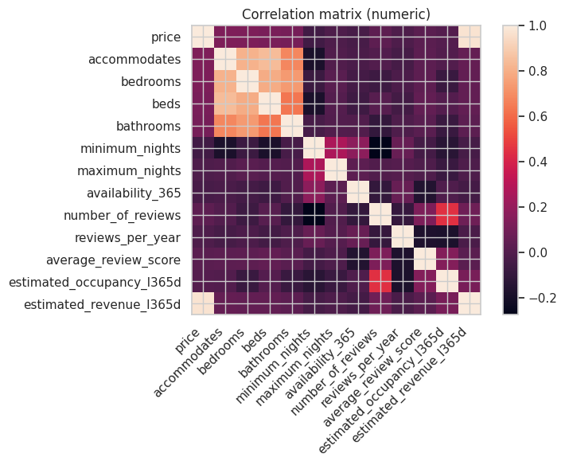

```python
#Correlation Heatmap
focus = [c for c in [
    'price','accommodates','bedrooms','beds','bathrooms',
    'minimum_nights','maximum_nights','availability_365',
    'number_of_reviews','reviews_per_year','average_review_score',
    'estimated_occupancy_l365d','estimated_revenue_l365d'
] if c in df.columns]

corr = df[focus].corr()
plt.figure(figsize=(8,6))
plt.imshow(corr, interpolation='nearest')
plt.xticks(range(len(focus)), focus, rotation=45, ha='right')
plt.yticks(range(len(focus)), focus)
plt.colorbar()
save_show('Correlation matrix (numeric)')
```

```python
# Export cleaned data to CSV
df.to_csv('listings_cleaned.csv', index=False)
```

# Part 2 Additional Fixes. Dropping Nulls for host, location, prices, reviews (and also doing Encoding)

## Dealing With some extra Nulls

```python
# % missing by column
na_rate = df.isna().mean().sort_values(ascending=False)
na_rate.head(20)
```

```
host_about                      0.498739
neighborhood_overview           0.495135
host_location                   0.232973
estimated_revenue_l365d         0.164144
price                           0.164144
bathrooms                       0.162883
beds                            0.162523
max_host_response_time_hours    0.150090
host_response_rate              0.150090
average_review_score            0.130811
reviews_per_year                0.130811
host_acceptance_rate            0.112793
host_neighbourhood              0.042703
bedrooms                        0.031532
description                     0.010991
bathrooms_text                  0.000721
host_total_listings_count       0.000360
host_since                      0.000360
host_id                         0.000000
name                            0.000000
dtype: float64
```

ooof. host_about and neighbourhood_overview has nearly 50% nulls!. host_location is also pretty high. Lets look at them

```python
df['host_about'].unique()
```

```
array(['I love to travel with my family in comfort and enjoy the ethos and community spirit of AirBNB. I also host on AirBNB so travelers can enjoy staying with us in Vancouver!\nBon Voyage !!',
       'I am from Vancouver and in my free time I enjoy Yoga, Cycling and exploring the neighborhoods of my hometown.\nLove slow travel',
       nan, ...,
       'After graduating from the medical university, I chose to be a journalist. I have been to more than 30 countries in the world. I love art, especially interior design. I hope my home can give you the feeling of "feeling at home".',
       'Sally and I love to travel and have enjoyed hosting guests in other homes that we have lived in. This is our primary home but  We’re flexible hosts who spend time at our cabin, and can stay in our laneway home when needed — so we’re able to accommodate a variety of booking dates for our gues…
       'Travel creates some of the most enjoyable moments in life.  I hope that wonderful new memories are made in our home that we share with you.'],
      shape=(1811,), dtype=object)
```

```python
'''
I am going to replace nulls with 'No description provided' and then analyze the text to see if there are any common themes or keywords that can be extracted. This might help in understanding the type of hosts and their offerings better.

I will also create a column called host_has_about which will be a boolean indicating whether the host has provided a description or not. Will use this for analysis later.

'''

df['host_has_about'] = df['host_about'].notna().astype(bool)

df['host_about'] = df['host_about'].fillna('No description provided')

df['host_about'].unique()
```

```
array(['I love to travel with my family in comfort and enjoy the ethos and community spirit of AirBNB. I also host on AirBNB so travelers can enjoy staying with us in Vancouver!\nBon Voyage !!',
       'I am from Vancouver and in my free time I enjoy Yoga, Cycling and exploring the neighborhoods of my hometown.\nLove slow travel',
       'No description provided', ...,
       'After graduating from the medical university, I chose to be a journalist. I have been to more than 30 countries in the world. I love art, especially interior design. I hope my home can give you the feeling of "feeling at home".',
       'Sally and I love to travel and have enjoyed hosting guests in other homes that we have lived in. This is our primary home but  We’re flexible hosts who spend time at our cabin, and can stay in our laneway home when needed — so we’re able to accommodate a variety of booking dates for our gues…
       'Travel creates some of the most enjoyable moments in life.  I hope that wonderful new memories are made in our home that we share with you.'],
      shape=(1811,), dtype=object)
```

```python
print(df[['host_about', 'host_has_about']].head())
```

```
                                          host_about  host_has_about
0  I love to travel with my family in comfort and...            True
1  I am from Vancouver and in my free time I enjo...            True
2                            No description provided           False
3  In my spare time I am pretty active - currentl...            True
4  We - Alexis and Sylvain - are the Artistic Dir...            True
```

## Neighbourhood Overview

```python
df['neighborhood_overview'].unique()
```

```
array(['The uber hip Main street area is a short walk of 6 minutes to the east.  Dozens of dining options.  Great supermarkets, butcher ,cafe, pub, tiki lounge, ethnic restaurants of all sorts.  Sprinkled with antique stores and retro clothing stores.  To the West, just down the hill from the Canada…
       "2 blocks away from the shopping area of Robson Street.<br />A short walk away to Trendy Yaletown with all its cafes, restaurants, waterfront seawall access. It's also an easy stroll to catch the aqua bus to Granville Island for fresh food shopping at the public market.",
       'Next block to Commercial Drive which has many buses, shops, restaurants, doctors, coffee shops, banks',
       ...,
       "🌿 Live by the Lake – Nature, Culture & Convenience in East Vancouver<br />Just a short walk from the beautiful Trout Lake (John Hendry Park), our home offers the rare charm of lakeside living in the heart of the city. Enjoy morning jogs by the water, yoga on the grass, or feeding ducks with …
       '📍 Prime Downtown Location – 58 Keefer Place, Vancouver<br />Conveniently located in the heart of downtown Vancouver, this condo offers unbeatable access to transit, shopping, dining, and entertainment.<br /><br />🚆 Transit Access<br />Just a 3-minute walk to Stadium–Chinatown SkyTrain Statio…
       'Located in the vibrant heart of Downtown Vancouver’s Yaletown district, this home offers the perfect blend of urban convenience and scenic charm. Enjoy tree-lined streets, waterfront parks, and trendy restaurants just steps away. The seawall, grocery stores, cafes, and boutique shops are all…
      shape=(2449,), dtype=object)
```

```python
'''
I am going to replace nulls with 'No description provided' and then analyze the text to see if there are any common themes or keywords that can be extracted. This might help in later determining if the lack of descriptions affect listings' performance.

I am also going to create a column called neighborhood_has_overview which will be a boolean indicating whether the neighborhood overview has been provided or not. Will use this for analysis later.

'''

df['neighborhood_has_overview'] = df['neighborhood_overview'].notna().astype(bool)

df['neighborhood_overview'] = df['neighborhood_overview'].fillna('No description provided')
df['neighborhood_overview'].unique()
```

```
array(['The uber hip Main street area is a short walk of 6 minutes to the east.  Dozens of dining options.  Great supermarkets, butcher ,cafe, pub, tiki lounge, ethnic restaurants of all sorts.  Sprinkled with antique stores and retro clothing stores.  To the West, just down the hill from the Canada…
       "2 blocks away from the shopping area of Robson Street.<br />A short walk away to Trendy Yaletown with all its cafes, restaurants, waterfront seawall access. It's also an easy stroll to catch the aqua bus to Granville Island for fresh food shopping at the public market.",
       'Next block to Commercial Drive which has many buses, shops, restaurants, doctors, coffee shops, banks',
       ...,
       "🌿 Live by the Lake – Nature, Culture & Convenience in East Vancouver<br />Just a short walk from the beautiful Trout Lake (John Hendry Park), our home offers the rare charm of lakeside living in the heart of the city. Enjoy morning jogs by the water, yoga on the grass, or feeding ducks with …
       '📍 Prime Downtown Location – 58 Keefer Place, Vancouver<br />Conveniently located in the heart of downtown Vancouver, this condo offers unbeatable access to transit, shopping, dining, and entertainment.<br /><br />🚆 Transit Access<br />Just a 3-minute walk to Stadium–Chinatown SkyTrain Statio…
       'Located in the vibrant heart of Downtown Vancouver’s Yaletown district, this home offers the perfect blend of urban convenience and scenic charm. Enjoy tree-lined streets, waterfront parks, and trendy restaurants just steps away. The seawall, grocery stores, cafes, and boutique shops are all…
      shape=(2449,), dtype=object)
```

```python
print(df[['neighborhood_overview', 'neighborhood_has_overview']].head())
```

```
                               neighborhood_overview  \
0  The uber hip Main street area is a short walk ...
1  2 blocks away from the shopping area of Robson...
2  Next block to Commercial Drive which has many ...
3  Lots of restaurants, coffee shops.<br />Easy a...
4  Lots of restaurants and boutiques just outside...

   neighborhood_has_overview
0                       True
1                       True
2                       True
3                       True
4                       True
```

## host_location nulls

```python
df['host_location'].unique()
```

```
array(['Vancouver, Canada', nan, 'Richmond, Canada', 'Abbotsford, Canada',
       'Lethbridge, Canada', 'West Vancouver, Canada',
       'Stuttgart, Germany', 'Toronto, Canada', 'New Orleans, LA',
       'Los Angeles, CA', 'West Hollywood, CA', 'Seattle, WA',
       'Fontainebleau, France', 'Regina, Canada', 'Pemberton, Canada',
       'British Columbia, Canada', 'Montreal, Canada', 'Gibsons, Canada',
       'Coquitlam, Canada', 'Whistler, Canada', 'Las Vegas, NV',
       'United States', 'Tokyo, Japan', 'Burnaby, Canada',
       'San Francisco, CA', 'Cobble Hill, Canada', 'Sliema, Malta',
       'Taiwan', 'New Boston, NH', 'New Westminster, Canada', 'Canada',
       'Halfmoon Bay, Canada', 'Valencia, Spain', 'Calgary, Canada',
       'Squamish, Canada', 'Kingston, Canada', 'Surrey, Canada',
       'Honolulu, HI', 'North Vancouver, Canada',
       'Frankston South, Australia', 'Victoria, Canada',
       'Melbourne, Australia', 'Port Moody, Canada', 'Mendoza, Argentina',
       'Seongnam-si, South Korea', 'Orlando, FL', 'San Mateo, Costa Rica',
       'Langley Township, Canada', 'Langley City, Canada',
       'Vancouver, WA', 'Bournemouth, United Kingdom', 'Ottawa, Canada',
       'Lions Bay, Canada', 'London, United Kingdom',
       'California, United States', 'Santa Rosa, CA', 'Hong Kong',
       'Edmonton, Canada', 'Saltair, Canada', 'White Rock, Canada',
       'Oakville, Canada', 'Langley, Canada', 'Dasmariñas, Philippines',
       'Batala, India', 'Maple Ridge, Canada', 'Philadelphia, PA',
       'Whitehorse, Canada', 'Inuvik, Canada', 'Delta, Canada',
       'Greater Vancouver A, Canada', 'Glenside, PA', 'São Paulo, Brazil',
       'Saskatoon, Canada', 'The Colony, TX', 'Kelowna, Canada',
       'Smithers, Canada', 'San Diego, CA', 'Berdychiv, Ukraine',
       'University Endowment Lands, Canada', 'Port Alberni, Canada',
       'Koszalin, Poland', 'Arlington, VA', 'Saltillo, Mexico',
       'Roberts Creek, Canada', 'China', 'Washington, DC', 'McLean, VA',
       'Neuilly-sur-Seine, France'], dtype=object)
```

```python
'''
Replace with nulls with 'No location provided'

I will also create a column called host_location_provided which will be a boolean indicating whether the host has provided a location or not. Will use this for analysis later.

'''

df['host_location_provided'] = df['host_location'].notna().astype(bool)

df['host_location'] = df['host_location'].fillna('No location provided')
df['host_location'].unique()
```

```
array(['Vancouver, Canada', 'No location provided', 'Richmond, Canada',
       'Abbotsford, Canada', 'Lethbridge, Canada',
       'West Vancouver, Canada', 'Stuttgart, Germany', 'Toronto, Canada',
       'New Orleans, LA', 'Los Angeles, CA', 'West Hollywood, CA',
       'Seattle, WA', 'Fontainebleau, France', 'Regina, Canada',
       'Pemberton, Canada', 'British Columbia, Canada',
       'Montreal, Canada', 'Gibsons, Canada', 'Coquitlam, Canada',
       'Whistler, Canada', 'Las Vegas, NV', 'United States',
       'Tokyo, Japan', 'Burnaby, Canada', 'San Francisco, CA',
       'Cobble Hill, Canada', 'Sliema, Malta', 'Taiwan', 'New Boston, NH',
       'New Westminster, Canada', 'Canada', 'Halfmoon Bay, Canada',
       'Valencia, Spain', 'Calgary, Canada', 'Squamish, Canada',
       'Kingston, Canada', 'Surrey, Canada', 'Honolulu, HI',
       'North Vancouver, Canada', 'Frankston South, Australia',
       'Victoria, Canada', 'Melbourne, Australia', 'Port Moody, Canada',
       'Mendoza, Argentina', 'Seongnam-si, South Korea', 'Orlando, FL',
       'San Mateo, Costa Rica', 'Langley Township, Canada',
       'Langley City, Canada', 'Vancouver, WA',
       'Bournemouth, United Kingdom', 'Ottawa, Canada',
       'Lions Bay, Canada', 'London, United Kingdom',
       'California, United States', 'Santa Rosa, CA', 'Hong Kong',
       'Edmonton, Canada', 'Saltair, Canada', 'White Rock, Canada',
       'Oakville, Canada', 'Langley, Canada', 'Dasmariñas, Philippines',
       'Batala, India', 'Maple Ridge, Canada', 'Philadelphia, PA',
       'Whitehorse, Canada', 'Inuvik, Canada', 'Delta, Canada',
       'Greater Vancouver A, Canada', 'Glenside, PA', 'São Paulo, Brazil',
       'Saskatoon, Canada', 'The Colony, TX', 'Kelowna, Canada',
       'Smithers, Canada', 'San Diego, CA', 'Berdychiv, Ukraine',
       'University Endowment Lands, Canada', 'Port Alberni, Canada',
       'Koszalin, Poland', 'Arlington, VA', 'Saltillo, Mexico',
       'Roberts Creek, Canada', 'China', 'Washington, DC', 'McLean, VA',
       'Neuilly-sur-Seine, France'], dtype=object)
```

```python
print(df[['neighborhood_overview', 'neighborhood_has_overview']].head())
```

```
                               neighborhood_overview  \
0  The uber hip Main street area is a short walk ...
1  2 blocks away from the shopping area of Robson...
2  Next block to Commercial Drive which has many ...
3  Lots of restaurants, coffee shops.<br />Easy a...
4  Lots of restaurants and boutiques just outside...

   neighborhood_has_overview
0                       True
1                       True
2                       True
3                       True
4                       True
```

## Price and Estimated Revenue Nulls

```python
'''
Since price and estimated revenue and reviews are crucial for our analysis, I will drop rows where either of these columns have null values. This will ensure that our dataset is complete for any financial analysis we plan to conduct.
'''
df = df.dropna(subset=['price', 'estimated_revenue_l365d', 'average_review_score', 'reviews_per_year'])
df.shape
```

```
(4053, 41)
```

# Bonus Experimentation and stats. (DONT SHOW PROF unless I have a solid understanding of the stats)

```python
# % missing by column
na_rate = df.isna().mean().sort_values(ascending=False)
na_rate.head(20)
```

```
host_response_rate              0.068098
max_host_response_time_hours    0.068098
host_neighbourhood              0.040464
host_acceptance_rate            0.035036
description                     0.008142
bathrooms_text                  0.000740
host_since                      0.000493
host_total_listings_count       0.000493
bathrooms                       0.000493
bedrooms                        0.000247
beds                            0.000247
host_about                      0.000000
host_location                   0.000000
name                            0.000000
id                              0.000000
neighborhood_overview           0.000000
host_id                         0.000000
latitude                        0.000000
neighbourhood_cleansed          0.000000
host_identity_verified          0.000000
dtype: float64
```

```python
df.info()
```

```
<class 'pandas.core.frame.DataFrame'>
Index: 4053 entries, 0 to 5536
Data columns (total 41 columns):
 #   Column                        Non-Null Count  Dtype
---  ------                        --------------  -----
 0   id                            4053 non-null   int64
 1   name                          4053 non-null   object
 2   description                   4020 non-null   object
 3   neighborhood_overview         4053 non-null   object
 4   host_id                       4053 non-null   int64
 5   host_since                    4051 non-null   datetime64[ns]
 6   host_location                 4053 non-null   object
 7   host_about                    4053 non-null   object
 8   host_response_rate            3777 non-null   float64
 9   host_acceptance_rate          3911 non-null   float64
```

[output cut: 33 more lines]

### Some experimentation with encoding (Don't show PROF)

```python
card = df.nunique(dropna=False).sort_values(ascending=False)
print(card)
```

```
id                              4053
name                            4008
amenities                       3978
description                     3706
longitude                       3608
latitude                        3421
reviews_per_year                3292
host_id                         2865
estimated_revenue_l365d         2299
host_since                      2164
neighborhood_overview           1915
host_about                      1377
average_review_score             728
price                            724
number_of_reviews                393
availability_365                 366
maximum_nights                   110
estimated_occupancy_l365d         80
host_acceptance_rate              75
host_neighbourhood                69
host_total_listings_count         66
host_location                     58
property_type                     44
host_response_rate                35
minimum_nights                    32
bathrooms_text                    23
neighbourhood_cleansed            23
accommodates                      16
bathrooms                         15
beds                              13
bedrooms                          10
max_host_response_time_hours       5
room_type                          3
host_identity_verified             2
host_is_superhost                  2
host_has_profile_pic               2
instant_bookable                   2
neighborhood_has_overview          2
host_has_about                     2
host_location_provided             2
has_availability                   1
dtype: int64
```

```python
cat_cols = df.select_dtypes(include=['object','category','bool']).columns

for c in cat_cols:
    print(f'\n=== {c} | dtype={df[c].dtype} | nunique={df[c].nunique(dropna=False)} ===')
    print(df[c].value_counts(dropna=False).head(15))
```

```
=== name | dtype=object | nunique=4008 ===
name
Warm Room In Shaughnessy                        4
Bright & Spacious Loft | Office & AC            2
08                                              2
g2b                                             2
Stunning Gastown Loft! 1200 sq ft & King Bed    2
Vancouver, Dundas St, Room on upstairs, U1      2
Coal Harbour Luxury Apartment                   2
26-1 Basement room                              2
Cozy Studio in Mount Pleasant                   2
Downtown single room near beach                 2
Private Spacious Room w/ Queen Bed Near UBC     2
Heart of Downtown Vancouver                     2
g1                                              2
Condo in Downtown Vancouver                     2
11-3                                            2
Name: count, dtype: int64

=== description | dtype=object | nunique=3706 ===
description
Enjoy easy access to everything from this perfectly located home base.                                                                                                                                                                                                                                      …
NaN                                                                                                                                                                                                                                                                                                         …
Take it easy at this unique and tranquil getaway.                                                                                                                                                                                                                                                           …
The suite way to stay in downtown Vancouver. Enjoy comforts of home with fully-equipped kitchens, functional living areas, personal outdoor balconies or patios, and convenient in-suite laundry at Level.                                                                                                  …
Enjoy a stylish experience at this centrally located place.                                                                                                                                                                                                                                                 …
This centrally located place is a peaceful escape and brings you back to the simple life.                                                                                                                                                                                                                   …
Relax with the whole family at this peaceful place to stay.                                                                                                                                                                                                                                                 …
Welcome to Level Yaletown – Seymour, where comfort meets boutique luxury in the heart of downtown Vancouver.<br /><br />Skip the cramped short-term rentals and generic hotel rooms. Whether you're here for work, play, or both, this spacious suite offers the perfect balance of home-style living and ho…
Situated in Vancouver, this private bedroom is located on the main floor of a home. It is 15 minutes from the airport and a 20-minute drive to downtown Vancouver. Public transit is convenient because of the proximity to the bus stops! The bus stop in front of the house goes to downtown Vancouver or …
Take a break and unwind at this peaceful oasis.                                                                                                                                                                                                                                                             …
This renovated suite in a character home is nestled between Cambie Village, Broadway medical and business corridor, mount pleasant tech hub & lively Main St. <br /><br />Explore the many restaurants, cafes, bakeries, grocery stores, gyms, yoga, and parks.<br /><br />Experience the close-by protected…
Bring the whole family to this great place with lots of room for fun.                                                                                                                                                                                                                                       …
The whole group will enjoy easy access to everything from this centrally located place.                                                                                                                                                                                                                     …
Book this centrally located home for groups and enjoy the convenience of being close to everything.                                                                                                                                                                                                         …
Welcome to your home away from home! <br />Located in Vancouver’s desirable Oakridge neighborhood, offering easy access to the city’s best attractions. <br />This space has everything you need to unwind and explore.<br />-Bright and airy living area with modern decor<br />-Fully equipped kitchen for…
Name: count, dtype: int64

=== neighborhood_overview | dtype=object | nunique=1915 ===
neighborhood_overview
```

[output cut: 188 more lines]

```
True     2030
False    2023
Name: count, dtype: int64

=== neighborhood_has_overview | dtype=bool | nunique=2 ===
neighborhood_has_overview
True     2164
False    1889
Name: count, dtype: int64

=== host_location_provided | dtype=bool | nunique=2 ===
host_location_provided
True     3126
False     927
Name: count, dtype: int64
```

```python
def summarize_uniques(df, cols=None, top=10):
    import pandas as pd
    if cols is None:
        cols = list(df.columns)
    else:
        cols = list(cols)  # ensure list, not Index
    rows = []
    for c in cols:
        vc = df[c].value_counts(dropna=False)
        rows.append({
            'column': c,
            'dtype': str(df[c].dtype),
            'nunique': df[c].nunique(dropna=False),
            'top_values': ', '.join(f'{k}:{int(v)}' for k,v in vc.head(top).items())
        })
    return pd.DataFrame(rows).sort_values('nunique', ascending=False)

summary = summarize_uniques(df, top=5)
print(summary)
```

```
                          column           dtype  nunique  \
0                             id           int64     4053
1                           name          object     4008
25                     amenities          object     3978
2                    description          object     3706
17                     longitude         float64     3608
16                      latitude         float64     3421
36              reviews_per_year         float64     3292
4                        host_id           int64     2865
33       estimated_revenue_l365d         float64     2299
5                     host_since  datetime64[ns]     2164
3          neighborhood_overview          object     1915
7                     host_about          object     1377
35          average_review_score         float64      728
26                         price         float64      724
```

[output cut: 70 more lines]

```python
card = df.nunique(dropna=False)
suggest = []
for c in df.columns:
    k = card[c]
    dt = df[c].dtype
    if dt == 'bool':
        enc = 'keep as 0/1'
    elif np.issubdtype(dt, np.number) or np.issubdtype(dt, np.datetime64):
        enc = 'numeric (no encoding)'
    elif k <= 30:
        enc = 'OneHotEncoder'
    elif k <= 80:
        enc = 'top-K OHE or Frequency'
    else:
        enc = 'text proxy (len/words) or target/freq/hash'
    suggest.append((c, k, str(dt), enc))
pd.DataFrame(suggest, columns=['column','nunique','dtype','suggested_encoding']).sort_values('nunique', ascending=False).head(20)
```

|  | column | nunique | dtype | suggested_encoding |
| --- | --- | --- | --- | --- |
| 0 | id | 4053 | int64 | numeric (no encoding) |
| 1 | name | 4008 | object | text proxy (len/words) or target/freq/hash |
| 25 | amenities | 3978 | object | text proxy (len/words) or target/freq/hash |
| 2 | description | 3706 | object | text proxy (len/words) or target/freq/hash |
| 17 | longitude | 3608 | float64 | numeric (no encoding) |
| 16 | latitude | 3421 | float64 | numeric (no encoding) |
| 36 | reviews_per_year | 3292 | float64 | numeric (no encoding) |
| 4 | host_id | 2865 | int64 | numeric (no encoding) |
| 33 | estimated_revenue_l365d | 2299 | float64 | numeric (no encoding) |
| 5 | host_since | 2164 | datetime64[ns] | numeric (no encoding) |
| 3 | neighborhood_overview | 1915 | object | text proxy (len/words) or target/freq/hash |
| 7 | host_about | 1377 | object | text proxy (len/words) or target/freq/hash |
| 35 | average_review_score | 728 | float64 | numeric (no encoding) |
| 26 | price | 724 | float64 | numeric (no encoding) |
| 31 | number_of_reviews | 393 | int64 | numeric (no encoding) |
| 30 | availability_365 | 366 | int64 | numeric (no encoding) |
| 28 | maximum_nights | 110 | int64 | numeric (no encoding) |
| 32 | estimated_occupancy_l365d | 80 | int64 | numeric (no encoding) |
| 9 | host_acceptance_rate | 75 | float64 | numeric (no encoding) |
| 11 | host_neighbourhood | 69 | object | top-K OHE or Frequency |

```python
#Time to drop some stuff.

#has_availability is not very useful since it is almost always True. I guess I am also dropping id and host_id since they are unique identifiers and won't help in analysis.
#df.drop(columns=['has_availability', 'id', 'host_id'], inplace=True)
df.drop(columns=['has_availability', 'host_id'], inplace=True)
```

# 3. More Graphing and Visualization

## Outlier Graph

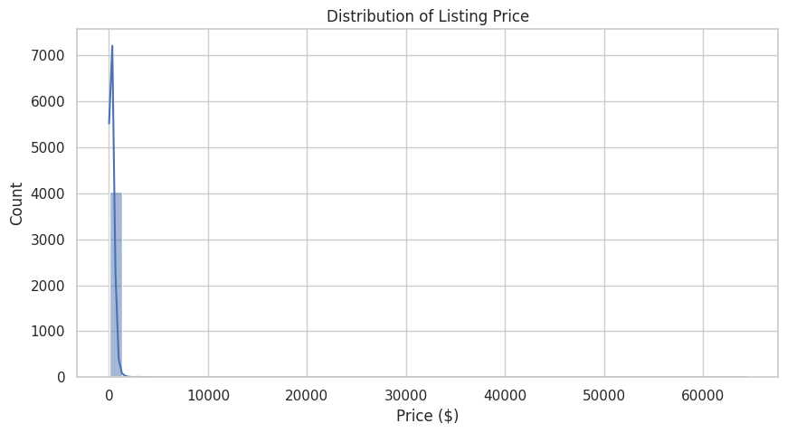

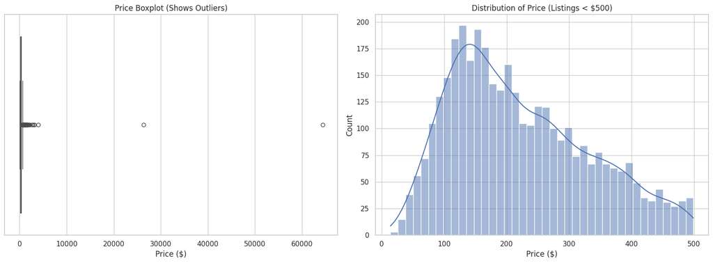

```python
import matplotlib.pyplot as plt
import seaborn as sns

sns.set_theme(style="whitegrid")

plt.figure(figsize=(10, 5))
sns.histplot(df['price'], bins=50, kde=True)
plt.title('Distribution of Listing Price')
plt.xlabel('Price ($)')
plt.show()

# Possible outliers. Likely Right skewed distribution.


fig, axes = plt.subplots(1, 2, figsize=(16, 6)) # 1 row, 2 cols

# Boxplot to clearly see outliers
sns.boxplot(x=df['price'], ax=axes[0])
axes[0].set_title('Price Boxplot (Shows Outliers)')
axes[0].set_xlabel('Price ($)')

# Filtered histogram for a better view
filtered_price = df[df['price'] < 500]['price'] # Filter to listings under $500
sns.histplot(filtered_price, bins=40, kde=True, ax=axes[1])
axes[1].set_title('Distribution of Price (Listings < $500)')
axes[1].set_xlabel('Price ($)')

plt.tight_layout()
plt.show()
```